# MK Deep Dive

D. Ford Hannum

6/18/2020

Going into a deep dive of the megakaryocytes (MKs) similar to the deep dive into the granulocytes.

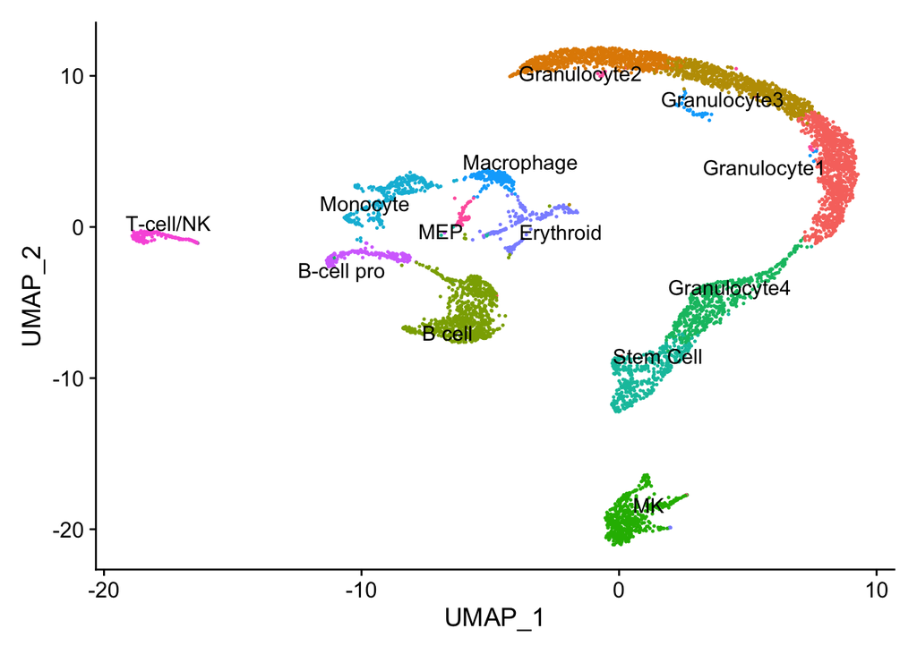

```r
wbm <- readRDS('./data/wbm_clustered_filtered_named.rds')

DimPlot(wbm, reduction = 'umap', label = T, repel = T) + NoLegend()
```

Results:

- *avg_logFC* : log fold-change of the average expression between the two groups. Positive values indicate that the gene is more highly expressed in the first group
- *pct.1* : the percentage of cells where the gene is detected in the first group (ie MKs)
- *pct.2* : the percentage of cells where the gene is detected in the second group (all other clusters)
- *p_val_adj* : adjusted p-value, based on bonferroni correctioni using all genes in the dataset

# MK cells

```r
m <- FindMarkers(wbm, ident.1 = 'MK', min.pct = 0.5, logfc.threshold = log(2))

m <- m[m$p_val_adj < 0.05,]

m <- m[order(m$avg_logFC, decreasing = T),]

cntrl_cells <- rownames(wbm@meta.data[wbm@meta.data$condition == 'control',])
mut_cells <- rownames(wbm@meta.data[wbm@meta.data$condition == 'mut',])

cwbm <- subset(wbm, cells = cntrl_cells)
mwbm <- subset(wbm, cells = mut_cells)

cM <- FindMarkers(cwbm, ident.1 = 'MK', min.pct = 0.5, logfc.threshold = log(2))
cM <- cM[cM$p_val_adj < 0.05,]
cM <- cM[order(cM$avg_logFC, decreasing = T),]

mM <- FindMarkers(mwbm, ident.1 = 'MK', min.pct = 0.5, logfc.threshold = log(2))
mM <- mM[mM$p_val_adj < 0.05,]
mM <- mM[order(mM$avg_logFC, decreasing = T),]

# write.csv(m,'./data/MK_DEG_all.csv', quote = F)
# write.csv(cM, './data/MK_DEG_controlcells.csv', quote = F)
# write.csv(mM, './data/MK_DEG_mutantcells.csv', quote = F)
```

DE genes for MK vs all: 145 control cells only, 416 mutant cells only, 319 all cells.

# MEP

```r
m <- FindMarkers(wbm, ident.1 = 'MEP', min.pct = 0.5, logfc.threshold = log(2))
m <- m[m$p_val_adj < 0.05,]
m <- m[order(m$avg_logFC, decreasing = T),]

cM <- FindMarkers(cwbm, ident.1 = 'MEP', min.pct = 0.5, logfc.threshold = log(2))
cM <- cM[cM$p_val_adj < 0.05,]
cM <- cM[order(cM$avg_logFC, decreasing = T),]

mM <- FindMarkers(mwbm, ident.1 = 'MEP', min.pct = 0.5, logfc.threshold = log(2))
mM <- mM[mM$p_val_adj < 0.05,]
mM <- mM[order(mM$avg_logFC, decreasing = T),]

# write.csv(m,'./data/MEP_DEG_all.csv', quote = F)
# write.csv(cM, './data/MEP_DEG_controlcells.csv', quote = F)
# write.csv(mM, './data/MEP_DEG_mutantcells.csv', quote = F)
```

DE genes for MEP vs all: 35 control cells only, 88 mutant cells only, 81 all cells.

# Erythrocytes

```r
m <- FindMarkers(wbm, ident.1 = 'Erythroid', min.pct = 0.5, logfc.threshold = log(2))
m <- m[m$p_val_adj < 0.05,]
m <- m[order(m$avg_logFC, decreasing = T),]

cM <- FindMarkers(cwbm, ident.1 = 'Erythroid', min.pct = 0.5, logfc.threshold = log(2))
cM <- cM[cM$p_val_adj < 0.05,]
cM <- cM[order(cM$avg_logFC, decreasing = T),]

mM <- FindMarkers(mwbm, ident.1 = 'Erythroid', min.pct = 0.5, logfc.threshold = log(2))
mM <- mM[mM$p_val_adj < 0.05,]
mM <- mM[order(mM$avg_logFC, decreasing = T),]

# write.csv(m,'./data/Ery_DEG_all.csv', quote = F)
# write.csv(cM, './data/Ery_DEG_controlcells.csv', quote = F)
# write.csv(mM, './data/Ery_DEG_mutantcells.csv', quote = F)
```

DE genes for Ery vs all: 186 control cells only, 96 mutant cells only, 147 all cells.